# Question

The continuous random variable $X$ follows the distribution shown by the density curve and spinner below. It has a mean of $\mu_{X}=32.15$ and standard deviation of $\sigma_{X}=17.14$.

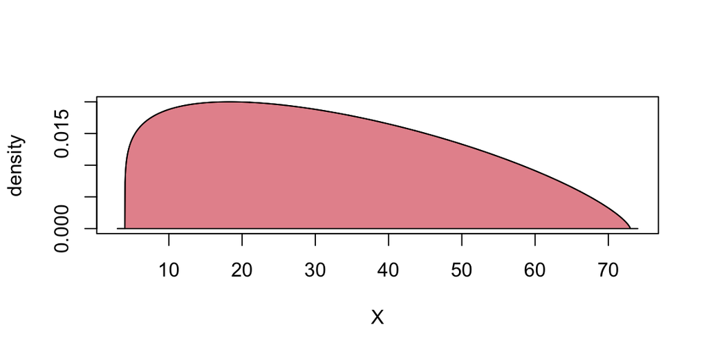

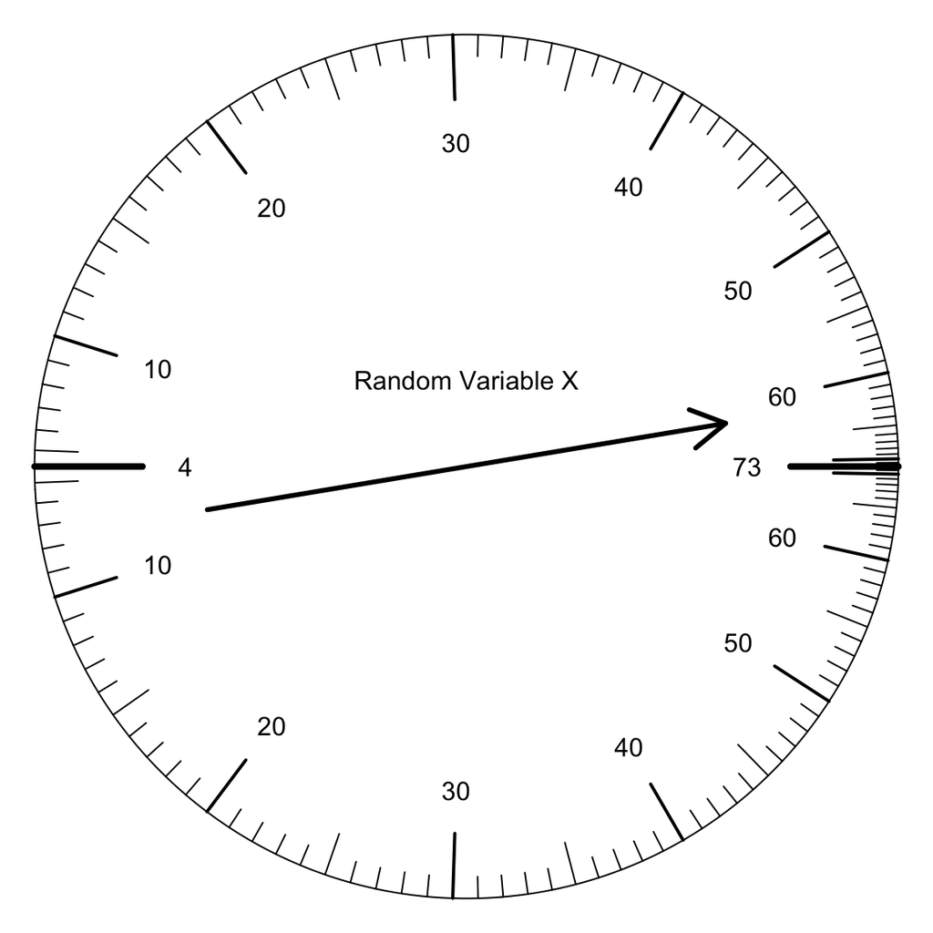

That spinner ($X$) will be fairly spun 416 times, and the **sample mean** of the spins will be recorded. Determine the probability that the random sample mean is less than 31.8.
$$P\left(\bar{X}<31.8\right) ~=~ \,?$$

(Even though single spins are **not** normally distributed, the random means will be normally distributed. See [central limit theorem](https://en.wikipedia.org/wiki/Central_limit_theorem).)

# Solution

[video](https://vimeo.com/531941126)

We use the central limit formulas for a random mean.
$$\mu_{\bar{X}} = \mu_{X} = 32.15$$
$$\sigma_{\bar{X}} = \frac{\sigma_{X}}{\sqrt{n}} =
\frac{17.14}{\sqrt{416}} = 0.8403576$$
So, we think the random mean is normally distributed with a mean of 32.15 and a standard deviation of 0.8403576.
$$\bar{X} \sim
N(32.15,\,0.8403576)$$

Calculate a $z$-score for the boundary.
$$z = \frac{31.8-32.15}{0.8403576}
= -0.4164893$$

You can round that to $z=-0.42$ or $z=-0.41$. Any of the following probabilities will get credit.
$$P(Z <
-0.4164893) = 0.338526$$
$$P(Z <
-0.42) = 0.3372$$
$$P(Z < -0.41) =
0.3409$$

To get the probability, you can use a spreadsheet. Either will work:

- `=NORMDIST(-0.4164893,0,1,TRUE)`
- `=NORMDIST(31.8,32.15,0.8403576,TRUE)`

Let’s draw a sketch.

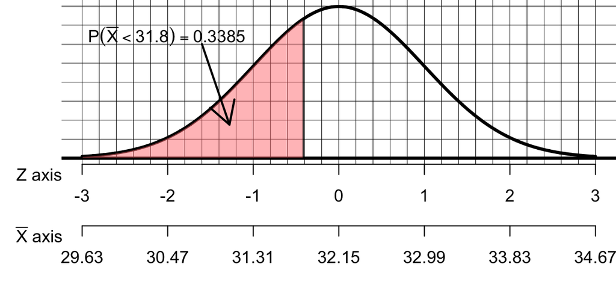

# Meta-information

extype: num exsolution: 0.338526 exname: prob ave less extol: 0.01